# Análisis de la contaminación en estaciones de monitoreo del aire seleccionadas de Lima Metropolitana, un estudio de 2015 a 2018

2023-04-28

## Importancia

La contaminación del aire es una problemática mundial y está de más decir que Lima Metropolitana se encuentra dentro de ella, ya que según estudios realizados por Air Quality Life Day Index (AQLI), Lima es considerada como una de las ciudades más contaminadas del continente. Es por esta razón que su estudio continuo es importante, ya que tiene un impacto directo en la salud de las personas. El presente informe analiza los tipos de contaminantes presentes en las estaciones de Lima Metropolitana basándose en la base de datos obtenida de SENAMHI , cabe resaltar que para este estudio se escogió cuatro distritos, Ate, Huachipa, San Borja y San Martín de Porres con respecto a los contaminantes (PM10, PM2.5, SO2, NO2, O3, CO). Este análisis se realizará mediante métodos estadísticos y de probabilidad. Esta problemática debe ser uno de los compromisos más importantes para Lima Metropolitana, ya que mejorar la calidad de aire es fundamental para una mejor calidad de vida y desarrollo urbano sostenible.

## Contexto

Para entender el informe se debe dar a concoer las siguientes partículas de exposición prolongada:

- **Material Particulado (PM)**: Particulas de pequeño tamaño, se dividen en PM2.5, que tienen un diámetro menor a 2.5 micrómetros, debido a su pequeña dimensión es dañino para la salud ya que afectan a los pulmones con mayor facilidad que como consecuencia puede causar inflamación, muerte temprana, mayormente estas partículas son tóxicas ya que están en relación con los metales como el Níquel, Plomo, entre otros. Y PM10, una partículas con un diámetro menor a 10 micrómetros y mayor a 2.5 micrómetros, los cuales al ser inhalados en altas proporciones se acumulan en los pulmones produciendo una disminución del funcionamiento pulmonar entre otros problemas de salud.
- **Monóxido de carbono (CO)**: Este contaminante proviene mayormente de los vehículos debido que todo se emite por una incompleta combustión de los vehículos a motor, este es uno de los principales contaminantes debido que si se inhalan en altas proporciones puede sustituir al oxígeno en la sangre como consecuencia produciendo problemas en la salud de las personas.
- **Dióxido de Azufre (SO2)**: Es el principal contaminante presente en los combustibles, centrales térmicas o refinerías de petróleo. Este gas denso puede perjudicar el sistema respiratorio si te encuentras expuesto durante 10 minutos a ello.
- **Dióxido de Nitrógeno (NO2)**: Este contaminante proviene de las industrias como el cemento, acero, vidrio, etc. Además produce que las ciudades con alto índice de contaminantes tengan una coloración gris amarillenta.
- **Ozono (O3)**: Es uno de los contaminantes más comunes, este contaminante se forma por los hidrocarburos orgánicos y los óxido de nitrógeno, esto se da mayormente en los escapes de los vehículos, estos contaminantes se combinan con la atmósfera, oxígeno y la luz solar, cabe resaltar que los niveles altos de ozono puede producir un aumento de los efectos del sistema inmunológico siendo dañino para la salud.

## Objetivos

### Objetivo general

- Evaluar la variabilidad temporal y espacial de la calidad del aire en Lima Metropolitana a través del análisis de datos relacionados a los contaminantes atmosféricos.

### Objetivos especificos

- Calcular la función de probabilidad de dos espacios muestrales derivados de las variables contaminantes mas peligrosas
- Encontrar dos pares de eventos relacionados a los contaminantes que sean independientes entre si o no
- Encontrar distribuciones de probabilidad discreta y continua que ayuden en posibles futuras situaciones

## Datos

### Proceso de recolección

Utilizamos una base de datos obtenida de la “Plataforma Nacional de Datos Abiertos”, una página web que recopila datos y los mantiene públicamente, los datos recopilados fueron dados por el SENAMHI, y nos muestra el registro horario de diferentes contaminantes en el aire, en un formato de 24 horas, registrados por distintas estaciones de monitoreo de calidad de aire en Lima Metropolitana entre los años 2010 y 2020.

## Carga de librerias

A partir de esta sección, se usara algunas librerias, por lo que el siguiente código se encargará de instalar y cargar todas las librerias necesarias

```r
if (!require(readr)){install.packages("readr");library(readr)}
if (!require(dplyr)){install.packages("dplyr");library(dplyr)}
if (!require(kableExtra)){install.packages("kableExtra");library(kableExtra)}
if (!require(DT)){install.packages("DT");library(DT)}
if (!require(knitr)){install.packages("knitr");library(knitr)}
if (!require(ggplot2)){install.packages("ggplot2");library(ggplot2)}
if (!require(corrplot)){install.packages("corrplot");library(corrplot)}
if (!require(hrbrthemes)){install.packages("hrbrthemes");library(hrbrthemes)}
if (!require(ggpubr)){install.packages("ggpubr");library(ggpubr)}
if (!require(lubridate)){install.packages("lubridate");library(lubridate)}
if (!require(descr)){install.packages("descr");library(descr)}
if (!require(stats)){install.packages("stats");library(stats)}
if (!require(mosaic)){install.packages("mosaic", repos = "http://cran.us.r-project.org");library(mosaic)}
```

## Descripción de variables de estudio:

Descripción variables

| Variable | Tipo | Restricciones |
| --- | --- | --- |
| Codigo Estación | Categorica Nominal | Código de autenficación, asignado por SENAMHI |
| Estacion | Categorica Ordinal | Estaciones de monitoreos de calidad de aire en Lima Metropolitana |
| Año | Categorica Ordinal | $x \in \mathbb{Z}^+ \quad : \quad 2010 \leq x \leq 2020$ |
| Mes | Categorica Ordinal | $x \in \mathbb{Z}^+ \quad : \quad 1 \leq x \leq 12$ |
| Dia | Categorica Ordinal | $x \in \mathbb{Z}^+ \quad : \quad 1 \leq x \leq 31$ |
| Hora | Categorica Nominal | $x \in \mathbb{Z}^+ \quad : \quad 1 \leq x \leq 24$ |
| PM.10 | Numerica Continua | $x \in \mathbb{R}^+ \quad : \quad 0 \leq x \leq 10000$ |
| PM.2.5 | Numerica Continua | $x \in \mathbb{R}^+ \quad : \quad 0 \leq x \leq 1000$ |
| SO2 | Numerica Continua | $x \in \mathbb{R}^+ \quad : \quad 0 \leq x \leq 1000$ |
| NO2 | Numerica Continua | $x \in \mathbb{R}^+ \quad : \quad 0 \leq x \leq 1000$ |
| O3 | Numerica Continua | $x \in \mathbb{R}^+ \quad : \quad 0 \leq x \leq 10000$ |
| CO | Numerica COntinua | $x \in \mathbb{R}^+ \quad : \quad 0 \leq x \leq 1000$ |

## Carga de datos

- Cargamos los datos que ya fueron limpiados en la primera entrega del informe

```r
BDC <- read_csv("bd_contaminacion_clean.csv")
```

## Análisis Descriptivo

### Descriptores Numéricos

Descriptores estadísticos de cada variable

|  | PM10 | PM2.5 | SO2 | NO2 | O3 | CO |
| --- | --- | --- | --- | --- | --- | --- |
|  | Min. : 5.53 | Min. : 3.00 | Min. : 0.10 | Min. : 0.10 | Min. : 0.10 | Min. : 1.6 |
|  | 1st Qu.: 40.69 | 1st Qu.: 12.60 | 1st Qu.: 4.60 | 1st Qu.: 16.00 | 1st Qu.: 5.40 | 1st Qu.: 360.4 |
|  | Median : 62.75 | Median : 19.30 | Median : 9.40 | Median : 25.30 | Median : 11.90 | Median : 676.8 |
|  | Mean : 75.76 | Mean : 25.29 | Mean : 13.77 | Mean : 29.42 | Mean : 16.23 | Mean : 818.0 |
|  | 3rd Qu.: 98.73 | 3rd Qu.: 31.50 | 3rd Qu.: 17.90 | 3rd Qu.: 37.70 | 3rd Qu.: 23.70 | 3rd Qu.:1118.4 |
|  | Max. :621.00 | Max. :233.40 | Max. :196.70 | Max. :197.20 | Max. :125.30 | Max. :5917.3 |

##### Análisis

- A partir de esta información es posible darse cuenta las probabilidades que posiblemente tomen ciertas variables

### Descriptores Gráficos

#### Univariado

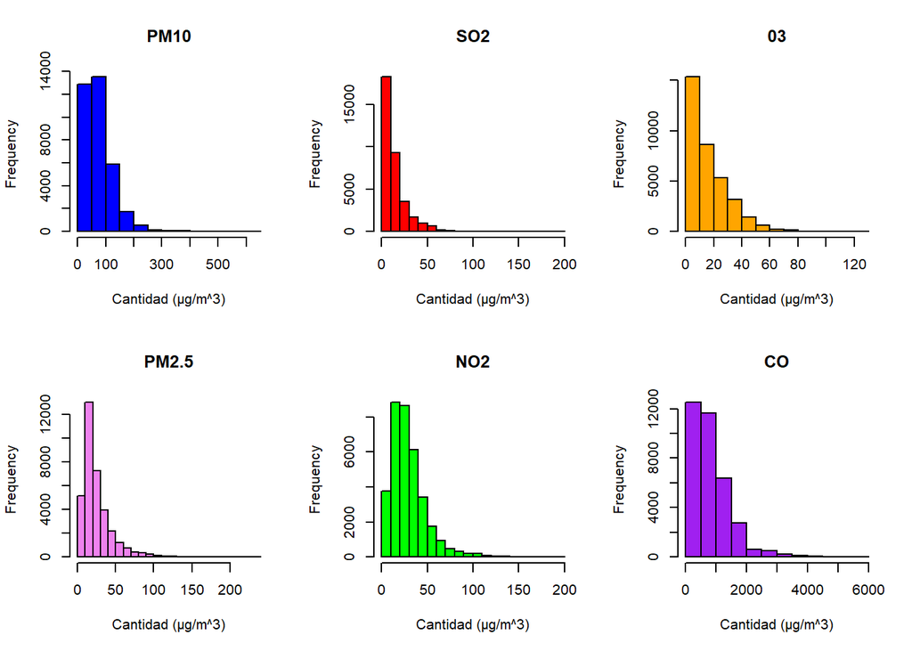

- **PM 10 (Partículas de 2.5 a 10 µm)**
  - Encontramos que la cantidad de contaminantes esta comúnmente entre 50 y 100 $\mu g/m^3$
- **PM 2.5 (Partículas menores a 2.5 µm)**
  - Encontramos que la cantidad de contaminantes esta comúnmente entre 10 y 20 $\mu g/m^3$
- **SO2 (Dióxido de azufre)**
  - Encontramos que la cantidad de contaminantes esta comúnmente entre 0 y 10 $\mu g/m^3$
- **NO2 (Dióxido de nitrógeno)**
  - Encontramos que la cantidad de contaminantes esta comúnmente entre 10 y 20 $\mu g/m^3$
- **O3 (Ozono)**
  - Encontramos que la cantidad de contaminantes esta comúnmente entre 0 y 10 $\mu g/m^3$
- **CO (Monóxido de carbono)**
  - Encontramos que la cantidad de contaminantes esta comúnmente entre 0 y 500 $\mu g/m^3$
- Además, se observa que los contaminantes PM10 y CO presentan escalas mucho mas altas de concentración en comparación de los otros contaminantes atmosféricos.

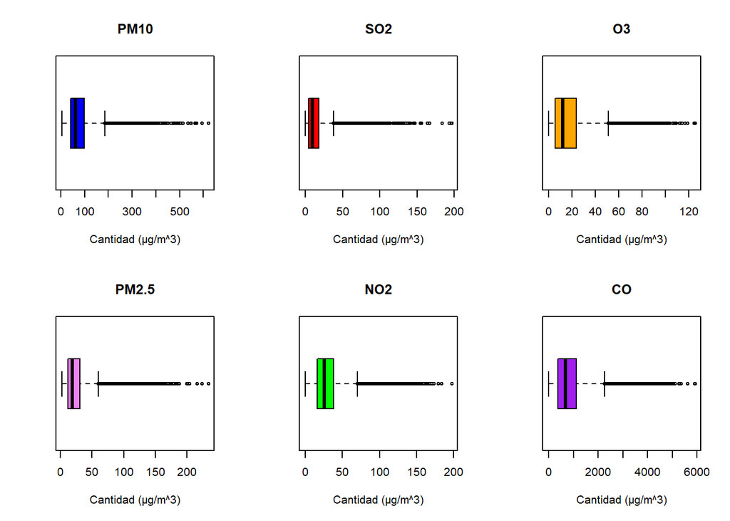

- Se puede observar que hay mayor cantidad de datos atípicos del contaminante CO a comparación de los demás contaminantes, recordar que este contaminantes proviene principalmente de vehículos a motor.
- Cabe resaltar que se trabajó con los datos atípicos pero se debe considerar que estas cantidades de partículas son captados por sensores que están calibrados.

##### Análisis

- Guiándonos de los gráficos, los histogramas nos pueden dar una idea de como serían las distribuciones en el caso de las variables (contaminantes) si las tomáramos como variables aleatorias continuas

#### Bivariado

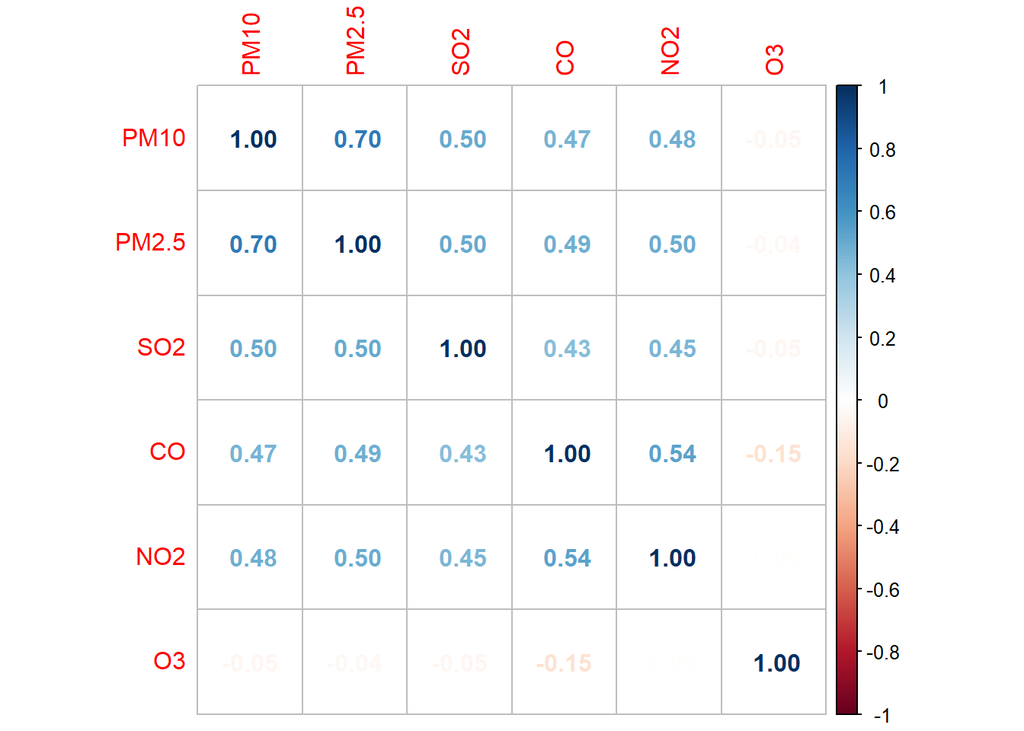

- Guiándonos de la gráfica de correlación, tomamos como principales posibles candidatos para tener eventos independientes a las variables con correlación menores a 0.5, las mayores iguales a 0.5, las tomaremos como posibles candidatos para tener eventos dependientes.

## Análisis Probabilístico

### Probabilidad Empírica

#### Elección de variables

- Escogeremos las variables O3 Y PM 2.5
- Escogemos estas variables ya que,ambas variables están presentes en el ambiente urbano y tienen impacto en la calidad del aire y la salud humana.
- El PM2.5 es un material muy fino y es capaz de ingresar por el sistema respiratorio, así como también transportar compuestos tóxicos, por lo que se considerada peligroso.
- El O3, es un gas que se forma a partir de reacciones químicas, y puede ser perjudicial para la salud humana debido a que en altas concentraciones pueden causar irritación en las diversas zonas, inflamación pulmonar y enfermedades respiratorias, así como también tiene impacto en el medio ambiente.

#### Espacio muestral

- Ya que las variables seleccionadas son continuas, se usara intervalos y marcas de clase para definir los eventos
- Para seleccionar el tamaño de los intervalos se usara la regla de Sturgess, donde: $Amplitud = \frac{Rango}{k}$. Donde k se calcula como: $k = 1 + log2(n)$
- Una vez hallamos el tamaño de los intervalos, obtenemos los intervalos, y luego damos marcas de clase a cada intervalo, que será la suma de los extremos de cada intervalo, dividido 2.
- También calculamos la cantidad de apariciones del contaminante en cada intervalo
- La siguiente función se encargara de todo ello

```r
frecTable = function(x, min, max) {
  kSturges <- 1 + log2(length(x))
  amplitud <- (max - min) / kSturges
  intervals <- seq(min(x), max(x) + amplitud, amplitud)
  x_cut <- cut(x, breaks = intervals, include.lowest = TRUE)
  levels_ <- levels(x_cut)
  marca_clase <-
    sapply(seq(1, length(intervals) - 1, 1), function(i) {
      intermedio <- round((intervals[i] + intervals[i + 1]) / 2, 0)
      return(intermedio)
    })
  apariciones <- as.vector(table(x_cut))
  freqs <-
    data.frame(
      "Intervalos-i" = levels_,
      "MarcaDeClase-Mi" = marca_clase,
      "ProbabilidadAbsoluta" = apariciones
    )
  return(freqs)
}
```

#### Espacio muestral de eventos definidos a partir de O3

##### Eventos atómicos definidos a partir de O3

- Sean los eventos atómicos de un espacio muestral **Ω_1** dado por: **“Seleccionar un registro tal que la cantidad de contaminantes O3 registrados este en el intervalo con marca de clase $M_i$”**
- **El espacio muestral de estos eventos seria:**

Espacio muestral de O_1

| Intervalos.i | MarcaDeClase.Mi | ProbabilidadAbsoluta |
| --- | --- | --- |
| [0.1,7.88] | 4 | 12349 |
| (7.88,15.7] | 12 | 8536 |
| (15.7,23.4] | 20 | 5174 |
| (23.4,31.2] | 27 | 3759 |
| (31.2,39] | 35 | 2446 |
| (39,46.8] | 43 | 1295 |
| (46.8,54.6] | 51 | 684 |
| (54.6,62.3] | 58 | 361 |
| (62.3,70.1] | 66 | 121 |
| (70.1,77.9] | 74 | 100 |
| (77.9,85.7] | 82 | 33 |
| (85.7,93.5] | 90 | 29 |
| (93.5,101] | 97 | 20 |
| (101,109] | 105 | 11 |
| (109,117] | 113 | 4 |
| (117,125] | 121 | 3 |
| (125,132] | 128 | 1 |

##### Función de probabilidad del espacio muestral **Ω_1**

Tabla de probabilidades de datos agrupados O3

| Intervalos_i | MarcasDeClase_Mi | Frecuencias_Absolutas | Probabilidad_Empirica |
| --- | --- | --- | --- |
| [0.1,7.88] | 4 | 12349 | 0.3535761 |
| (7.88,15.7] | 12 | 8536 | 0.2444025 |
| (15.7,23.4] | 20 | 5174 | 0.1481418 |
| (23.4,31.2] | 27 | 3759 | 0.1076276 |
| (31.2,39] | 35 | 2446 | 0.0700338 |
| (39,46.8] | 43 | 1295 | 0.0370784 |
| (46.8,54.6] | 51 | 684 | 0.0195843 |
| (54.6,62.3] | 58 | 361 | 0.0103361 |
| (62.3,70.1] | 66 | 121 | 0.0034645 |
| (70.1,77.9] | 74 | 100 | 0.0028632 |
| (77.9,85.7] | 82 | 33 | 0.0009449 |
| (85.7,93.5] | 90 | 29 | 0.0008303 |
| (93.5,101] | 97 | 20 | 0.0005726 |
| (101,109] | 105 | 11 | 0.0003150 |
| (109,117] | 113 | 4 | 0.0001145 |
| (117,125] | 121 | 3 | 0.0000859 |
| (125,132] | 128 | 1 | 0.0000286 |